# Week 2 Basic Graphics

# Instructions

## Before you start

This practical will be run using *posit.cloud* to avoid individual machine troubleshooting. You will find it helpful to have several resources close at hand: The lecture slides, [Chapter 5 of the R Book](https://onlinelibrary.wiley.com/doi/10.1002/9781118448908.ch5), and [the ggplot2 Book](https://ggplot2-book.org/). The R help will be indispensable for completing this exercise, remember for any `function()` you can type ?function to quickly pull up the help page.

You will also need to know how to type a `~` (tilde) on your computer.

## The goal

This practical will allow you to practice making basic data visualisations using R.

## Learning objectives

1. Produce a scatterplot using R base graphics and ggplot2
2. Produce a barplot using R base graphics
3. Produce a histogram using R base graphics and ggplot2
4. Produce a boxplot using R base graphics and ggplot2
5. Modify the labeling and presentation of R graphics to effectively communicate your message.

## The way it’s going to be run.

Write your own `R`-code and run it. That is the best way to learn how this program works. Also, you have an excellent Teaching assistant resource - ask him and/or me all the questions you have.

The text in the blue box marked as **Your task:** states what you need to do

```r
# The code in the window marked like this shows where you need to write your code
#
# If I ask you to assess the result or answer a question, you should write the text here as a comment starting with two hashes (##)
```

## Assessment.

Submit your `R-markdown` file via BrightSpace - **The assessment is a Pass/Fail based on how you write and annotate the code - You need to show us you know what you are doing and NOT copying someone else’s code.**

## Base graphics scatterplot

Ten people were surveyed to find out their height (in cm) and their shoe size (European):

| Name | Height (cm) | Shoe size (EU) |
| --- | --- | --- |
| Joe | 175 | 42 |
| Mary | 168 | 38 |
| Jane | 178 | 44 |
| Rasmus | 166 | 36 |
| Morten | 155 | 34 |
| Pia | 185 | 42 |
| Simon | 196 | 50 |
| Freja | 172 | 41 |
| Martin | 188 | 45 |
| Anna | 167 | 39 |

**Your task:** Reproduce this table as a dataframe in R. First assign the two variables to vectors called `name`, `height` and `shoesize`, then turn this into a dataframe called `height_df` with columns the same names as the vectors.

```r
#Assign the three variables to vectors
name <- c('Joe', 'Mary', 'Jane', 'Rasmus', 'Morten', 'Pia', 'Simon', 'Freja', 'Martin', 'Anna')
height <- c(175, 168, 178, 166, 155, 185, 196, 172, 188, 167)
shoesize <- c(42, 38, 44, 36, 34, 42, 50, 41, 45, 39)
#Make a dataframe called height_df
height_df <- data.frame(cbind(name,height,shoesize))
```

Note that you can check that your dataframe looks like you expect it should by clicking on its name in the top right-hand panel on *posit.cloud*.

**Your task:** Using R base graphics, make a scatterplot with height on the x axis and shoe size on the y axis, taking the data from the dataframe. Label axes correctly including units.

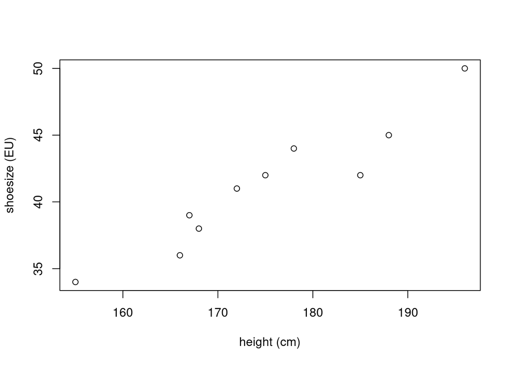

```r
#Make a scatterplot
plot(data = height_df, x = height, y = shoesize, xlab = 'height (cm)', ylab = 'shoesize (EU)')
```

Now the appearance of this plot can be modified, for example the appearance of each of the points. For a guide to this type `?points` to read the help file for points - the paramters from `points()` can also be included in the `plot()` to change the appearance of points in that plot.

**Your task:** Modify the above scatterplot so that values are indicated by solid red triangles.

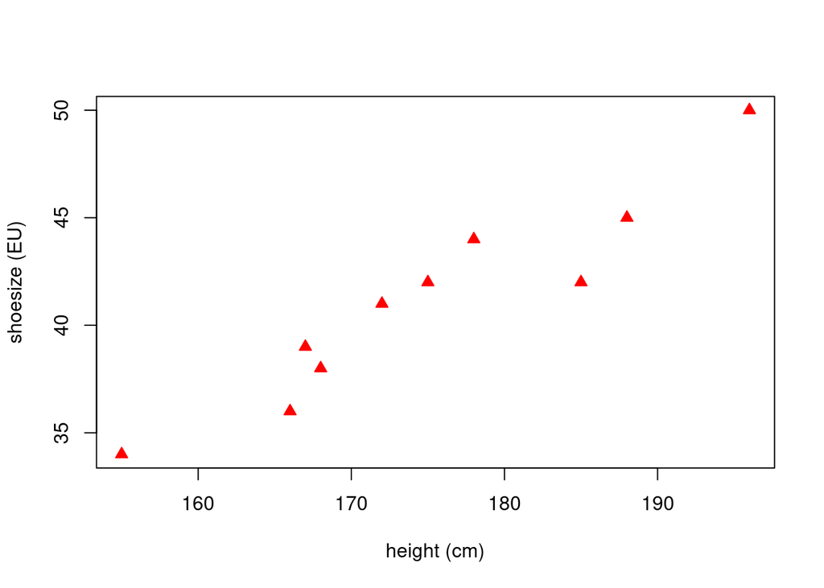

```r
#Modify the above scatterplot so that values are indicated by by solid
#red triangles.
plot(data = height_df, x = height, y = shoesize, xlab = 'height (cm)', ylab = 'shoesize (EU)', pch = 24, col = 'red', bg = 'red')
```

Each of the points (or red triangles) on the above plots represents an individual from the dataset. Let’s assume that you want to see which dot each person belongs to - you decide to print their name on the right-hand-side of each point. You can achieve this using the `text()` function, and you will need to read its help file carefully to understand how to achieve this. You may also need to modify the plotting area (limits) to read all the names.

**Your task:** Modify the above scatterplot so that the name of each individual is listed next to their data point.

[figure not shown]

```r
#Modify the above scatterplot so that the name of each individual
#is listed next to their data point.
plot(x = height_df$height, y = height_df$shoesize, xlab = 'height (cm)', ylab = 'shoesize (EU)', pch = 24, col = 'red', bg = 'red')

text(height_df$height, height_df$shoesize, labels = height_df$name, pos = 4)
```

## Base graphics barplot

Now let’s look at barplots.

**Your task:** Make a barplot containing vertical bars, each bar showing the height of an individual. Make sure that the y axis is correctly labeled including units.

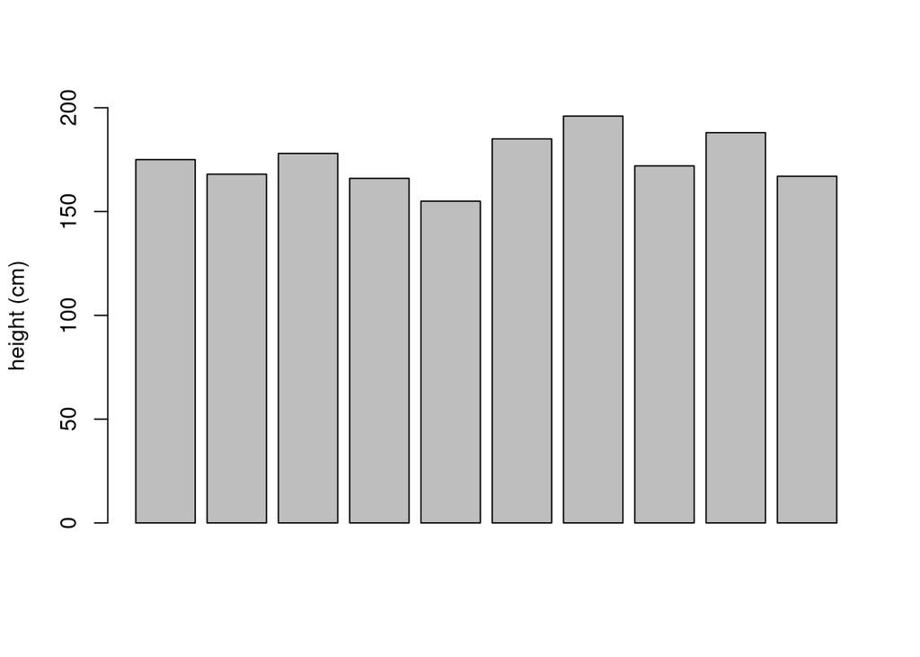

```r
#Make a barplot containing vertical bars, each bar showing the
#height of an individual.
barplot(height, ylab = 'height (cm)', ylim = c(0,200))
```

Now let’s make three changes to this barplot. First of all, make the bars horizontal so that the height is on the x axis. Secondly, label the y axis with the names of the individuals whose heights you are plotting. You will find the information you need for this in the help for `barplot` and `par`.

**Your task:** Make a barplot containing horizontal bars, each bar showing the height of an individual. Each individual bar should be labeled with the name of the individual. The names should also be written horizontally, which can be achieved on the y axis by the use of the `las=1` parameter than you can read more about in the help for `par()`.

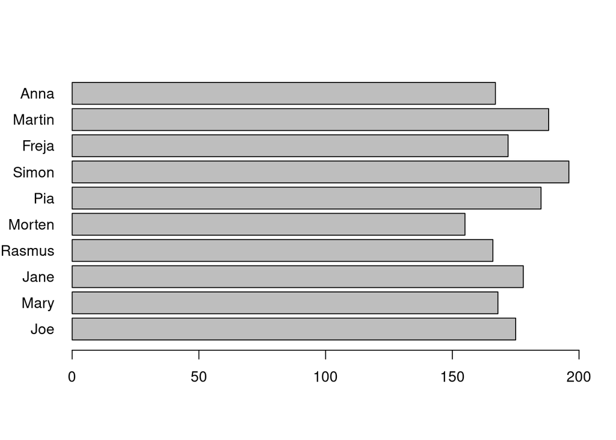

```r
#Horizontal barplot
barplot(height, horiz = TRUE, names = name, las = 1, xlim = c(0,200))
```

## Base graphics histogram

The following exercises will make use of the [Palmer Penguins Dataset](https://allisonhorst.github.io/palmerpenguins/). Download the file `penguins.xlsx` from Brightspace and Upload it to your project on *posit.cloud* using the *Files* tab in the bottom right-hand pane. Then import the dataset to R using `read_xlsx()` from the `readxl` package.

```r
#First load the package
library(readxl)
#Then import the dataset
penguins_df <- read_xlsx("penguins.xlsx")
```

Now let’s get to know this dataset a little bit. Click on the `penguins_df` dataframe in the upper right hand pane to view the data.

**Your task:** Assess the dataset. What is each observation of? What variables were recorded? How many observations are there?

```r
#What is each observation of?
##one individual
#What variables are there?
##8 variables shown below
colnames(penguins_df)
```

```
## [1] "species"           "island"            "bill_length_mm"
## [4] "bill_depth_mm"     "flipper_length_mm" "body_mass_g"
## [7] "sex"               "year"
```

```r
#How many observations are there?
##344
```

Now let’s explore the data using a histogram.

**Your task:** Produce a histogram of the penguins’ body mass, with a neat title and the x axis correctly labeled with units. What mass range is the most common?

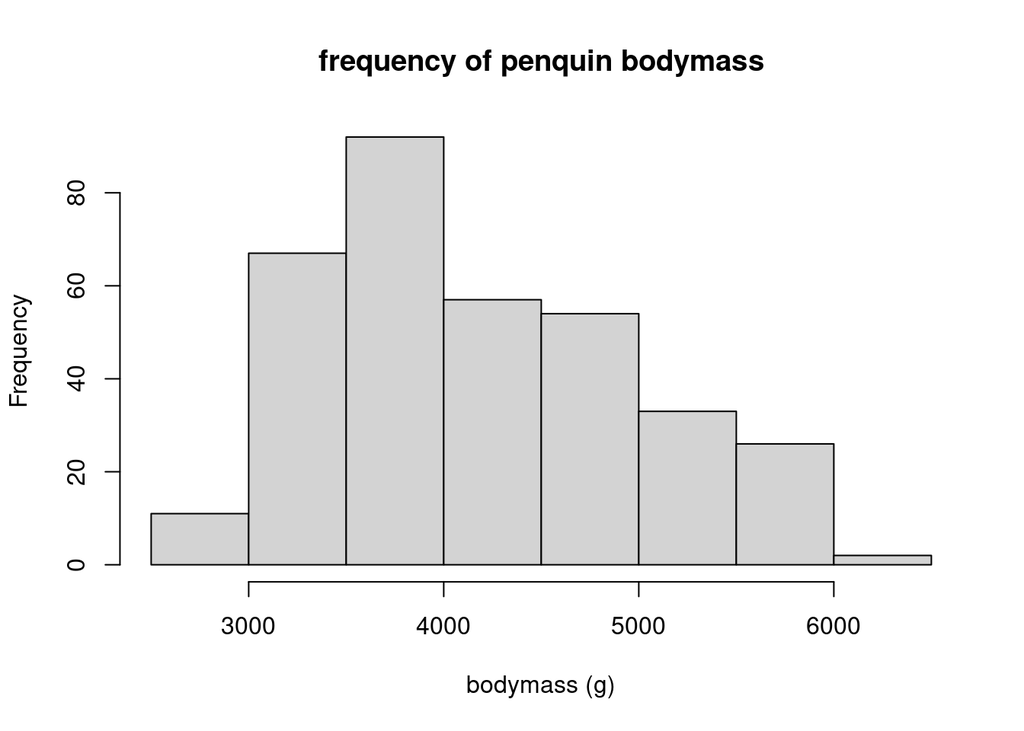

```r
#A histogram of the penguins' body mass
hist(penguins_df$body_mass_g, xlab = 'bodymass (g)', main = 'frequency of penquin bodymass')
```

```r
#What mass range is the most common?
##3.5-4.0 kilogram
```

## Base graphics Box-and-Whisker Plot

Now let’s explore the data using a box-and-whisker plot.

**Your task:** Produce a box-and-whisker of the penguins’ body mass, with the y axis correctly labeled with units. Are there outliers? Why/why not?

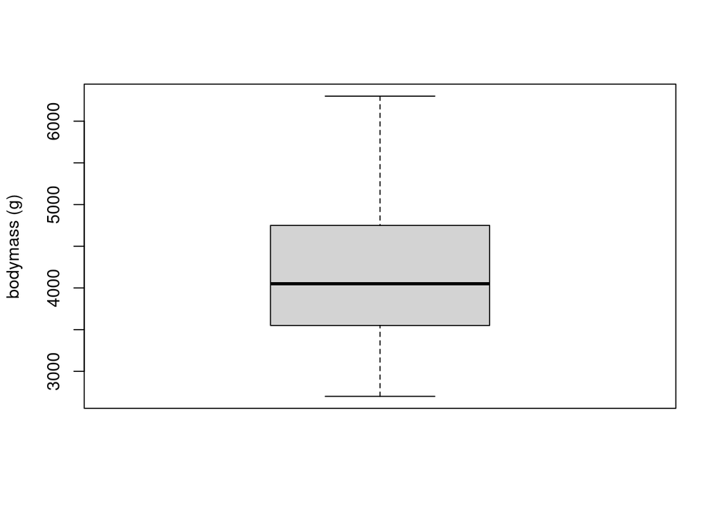

```r
#A box-and-whisker plot of the penguins' body mass
boxplot(penguins_df$body_mass_g, ylab = 'bodymass (g)')
```

```r
#Are there outliers? Why/why not?
##no, their are no dots
```

Of course there are several different penguin species we’re looking at here. Imagine you wanted to know the distribution for the body mass of each species.

**Your task:** Produce a box-and-whisker plot of the penguins’ body mass, with one box-and-whisker per penguin species. Which is the biggest species of penguin? Is every individual of the biggest species bigger than all of the next-biggest species?

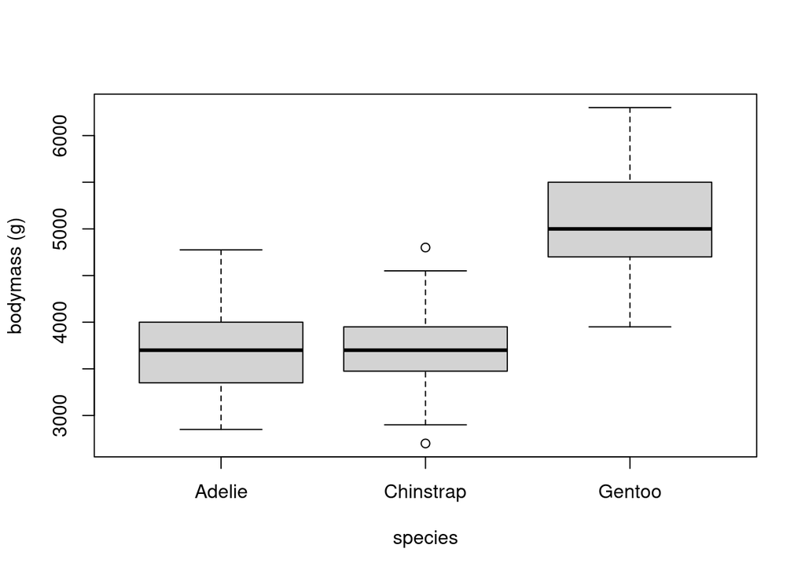

```r
#A box-and-whisker plot of the penguins' body mass, separated by species.
boxplot(data =penguins_df, body_mass_g~species, ylab = 'bodymass (g)')
```

```r
#Which is the biggest species of penguin?
##Gentoo
#Is every individual of the biggest species bigger than all of the next-biggest
#species?
##no
```

Now take a look at the help page for `boxplot()` by typing `?boxplot`. You will see that there is a parameter called `col` for making the boxes a colour other than grey.

**Your task:** Produce a box-and-whisker plot of the penguins’ body mass, with one box-and-whisker per penguin species. Give each species a different-coloured box.

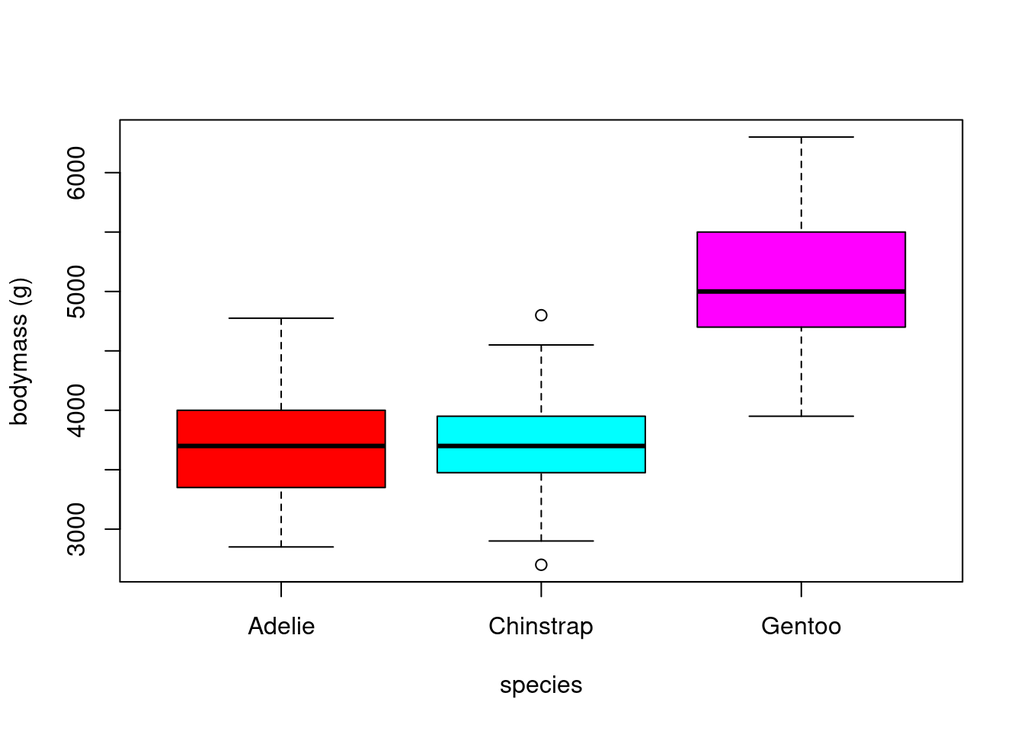

```r
#Produce a box-and-whisker plot of the penguins' body mass, with
#one box-and-whisker per penguin species. Give each species a different-coloured
#box.
co <- c('red','cyan','magenta')
boxplot(data =penguins_df, body_mass_g~species, ylab = 'bodymass (g)', col = co)
```

Remember, box plots can lie to you! Superimpose the individual data points on top of the above barplot to check whether the barplot is concealing an underlying distribution.

**Your task:** Produce a box-and-whisker plot of the penguins’ body mass, with one box-and-whisker per penguin species. Plot the mass for each individual penguin on top of the boxplot. Does it look like there is an underlying distribution that is invisible with the boxplot? Why or why not?

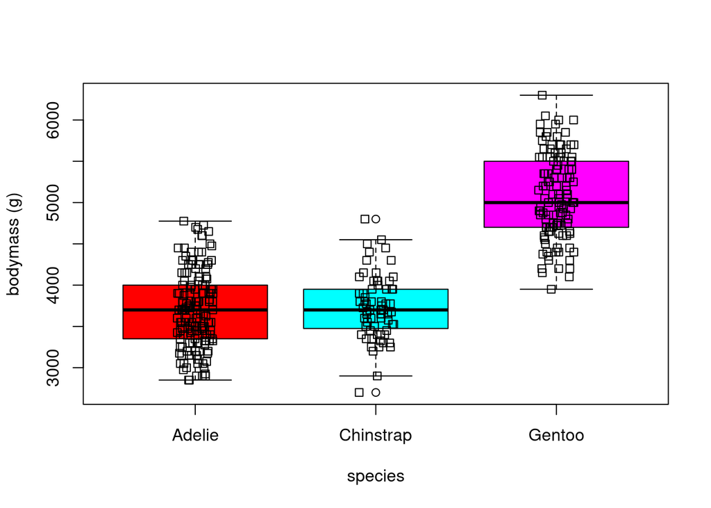

```r
#A box-and-whisker plot of the penguins' body mass, separated by species, with
#the individual data points plotted on top.
co <- c('red','cyan','magenta')
boxplot(data = penguins_df, body_mass_g~species, ylab = 'bodymass (g)', col = co)
stripchart(data = penguins_df, body_mass_g~species, add = TRUE, method = 'jitter', vertical = TRUE)
```

```r
#Does it look like there is an underlying
#distribution that is invisible with the boxplot? Why or why not?
##No, it looks about equally distributed with perhaps more point near the middle, which is fine.
```

## Scatterplots with ggplot2

The `ggplot2` package makes it easy to quickly map variables to aesthetics and apply them to geometric objects. This makes sophisticated plots simple! Let’s do this with the penguins dataset. First we’ll need to load the package.

```r
#Load the ggplot2 library
library(ggplot2)
```

Now let’s get started with a scatter plot.

**Your task:** Using `ggplot2`, make a plot where each point is a penguin, coloured by the species of penguin, with a shape indicating the island where the penguin was found. The point should be plotted such that the x axis indicates flipper length and y axis indicates bill length.

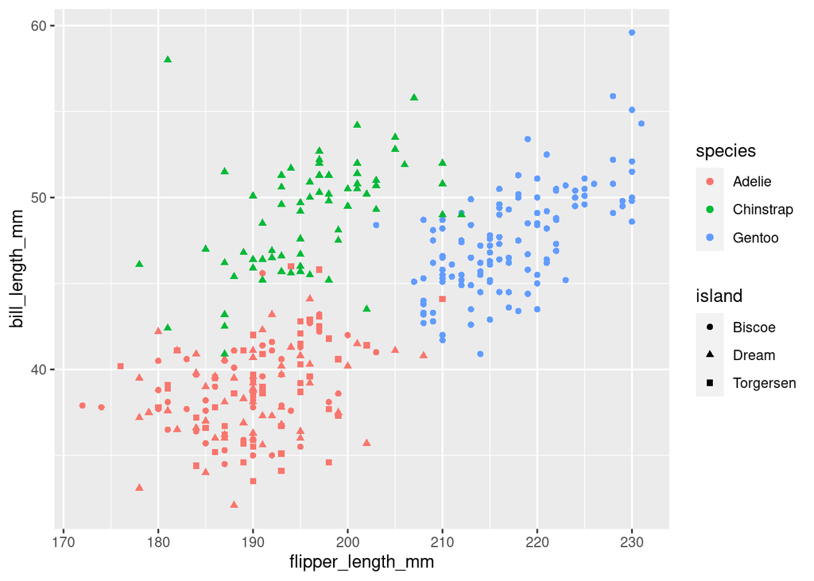

```r
#Using `ggplot2`, make a plot where each point is a penguin,
#coloured by the species of penguin, with a shape indicating the island where the
#penguin was found. The point should be plotted such that the x axis indicates
#flipper length and y axis indicates bill length.
ggplot(penguins_df, aes(flipper_length_mm, bill_length_mm, color = species, shape = island)) + geom_point()
```

This dataset is from observations made over the course of three years: 2007, 2008, and 2009. We can use a `ggplot2` function called `facet_wrap()` to view the data in three different panels, one year for each. Use the formula `~year` to divide the plot up in this way.

**Your task:** Remake the above plot, but divided into three facets, one for each year of observation. What trend do you notice in Gentoo penguins from 2007 to 2009?

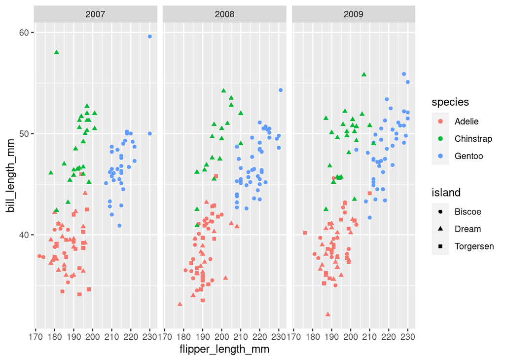

```r
#Remake the above plot, but divided into three panels, one for each
#year of observation.
ggplot(penguins_df, aes(flipper_length_mm, bill_length_mm, color = species, shape = island)) + geom_point() + facet_wrap(~year)
```

```r
#What trend do you notice in Gentoo penguins from 2007 to 2009?
##both bill and flipper increaces in lenght
```

**Your task:** Using `ggplot2`, make a plot where each point indicates a penguin plotted such that the x axis indicates flipper length and y axis indicates bill length, colour indicates species, and size indicates body mass. Make sure that all points are visible. What relationship between body size and flipper length becomes evident?

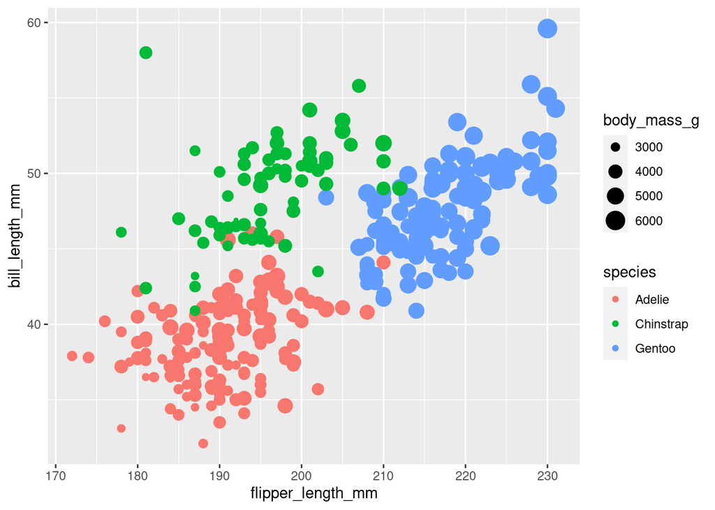

```r
#Using `ggplot2`, make a plot where each point indicates a penguin
#plotted such that the x axis indicates flipper length and y axis indicates bill
#length, colour indicates species, and size indicates body mass. Make sure that
#all points are visible.
ggplot(penguins_df, aes(flipper_length_mm, bill_length_mm, color = species, size = body_mass_g)) + geom_point()
```

```r
#What relationship between body mass and flipper length becomes evident?
##Proportional
```

## Histograms with ggplot2

**Your task:** Using `ggplot2`, make a histogram of all penguin body masses with the axis labeled correctly including units.

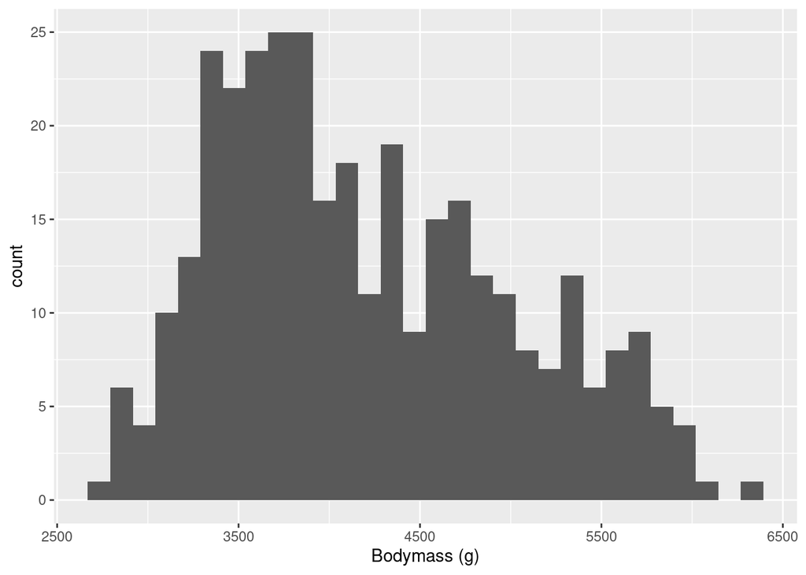

```r
#Using `ggplot2`, make a histogram of all penguin body masses with
#the axis labeled correctly including units.
ggplot(penguins_df, aes(x = body_mass_g)) + geom_histogram() + labs(x = 'Bodymass (g)')
```

Now we can see the distribution of body masses for all the penguins in the dataset. Let’s assume you want to know the body mass distribution for each separately, with each species labeled with a different colour. You will find the `position` parameter in `geom_histogram` useful. Also note that the aesthetics `fill` and `colour` do different things to your columns - choose the one you think best illustrates the data.

**Your task:** Using `ggplot2`, make a histogram of all penguin body masses with separate columns for each species. Each species should be indicated by a different colour. Columns of different colours should be adjacent to each other, rather than on top of each other. How do the aesthetics fill and colour differ from each other?

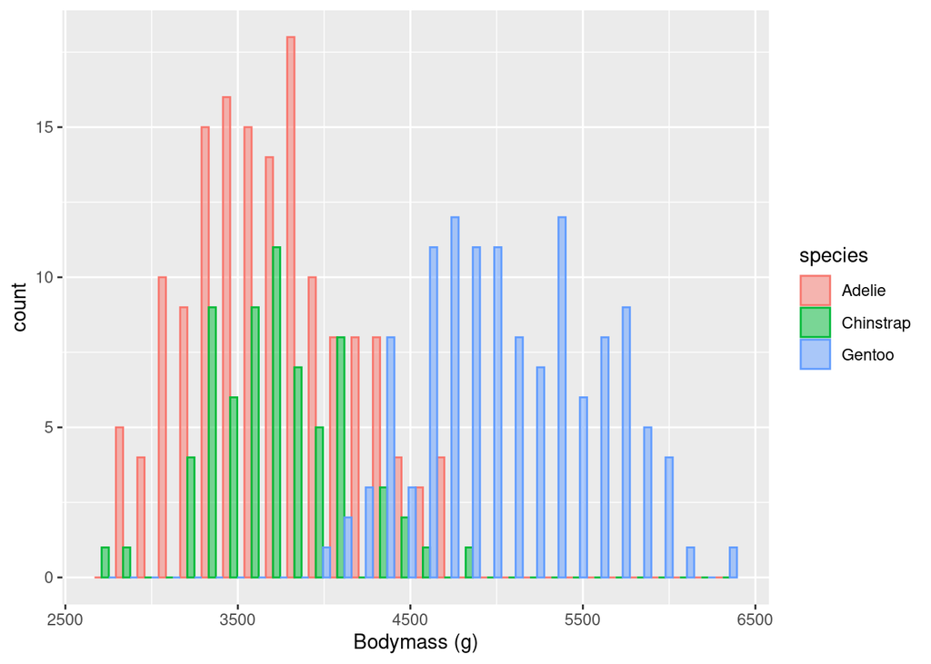

```r
#Using `ggplot2`, make a histogram of all penguin body masses with
#the axis labeled correctly including units.
ggplot(penguins_df, aes(x = body_mass_g, fill = species, color = species)) + geom_histogram(position = 'dodge', alpha = 0.5) + labs(x = 'Bodymass (g)')
```

```r
#How do the aesthetics fill and colour differ from each other?
##fill changes the color inside, while color changes the outline.
```

Now let’s see how different the penguin populations on the different islands are. Note that by default `facet_wrap` will place your facets side-by-side (in columns) instead of on top of each other (in rows), which is what is being asked for here. `facet_wrap` has parameters for the number of rows and columns that will help here.

**Your task:** Remake the above histogram, but in three different facets arranged on top of each other. Each facet should show the data for a different island. Which penguin species is on every island? Does the island seem to make a difference to the body mass of that species?

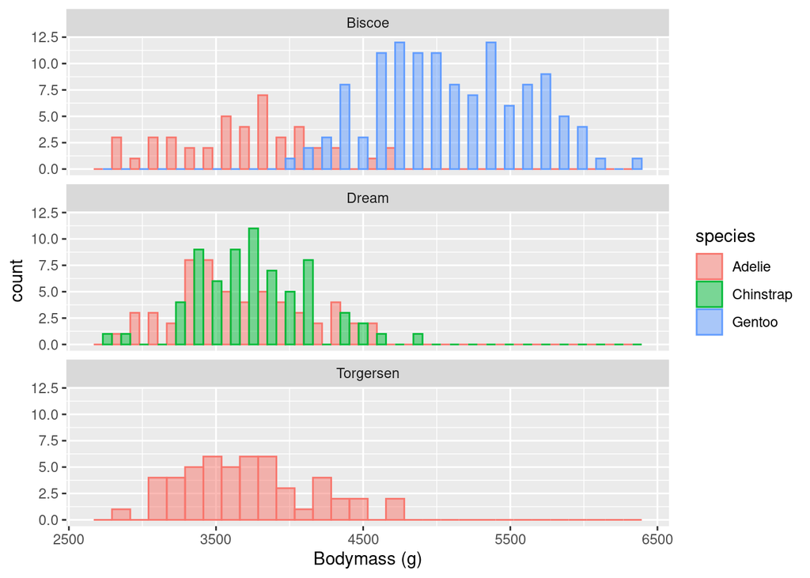

```r
#Remake the above histogram, but in three different facets
#arranged on top of each other. Each facet should show the data for a different
#island.
ggplot(penguins_df, aes(x = body_mass_g, fill = species, color = species)) + geom_histogram(position = 'dodge', alpha = 0.5) + labs(x = 'Bodymass (g)') + facet_wrap(~island, nrow = 3)
```

```r
#Which penguin species is on every island?
##A and G on Biscoe, A and C on Dream, A on Torgersen.
#Does the island seem to make a difference to the body mass of that species?
##inconclusive with C and G but A seams to be about the same distribution on each island.
```

## Boxplots with ggplot2

**Your task:** Using `ggplot2`, make a boxplot of all penguin body masses arranged by species. Label the y axis correctly with units.

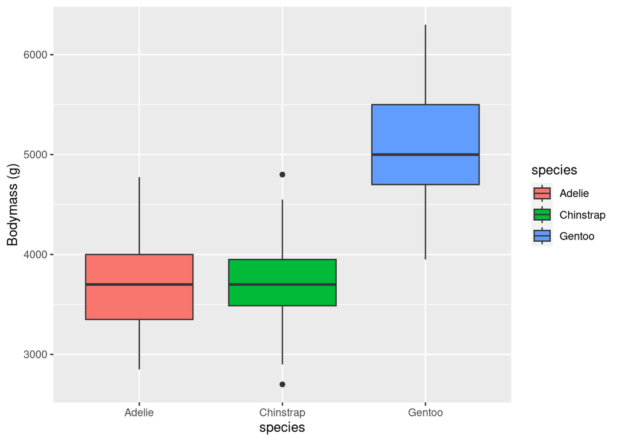

```r
#Using `ggplot2`, make a boxplot of all penguin body masses arranged by species.
#Label the y axis correctly with units.
ggplot(penguins_df, aes(y = body_mass_g, x = species, fill = species)) + geom_boxplot() + labs(y = 'Bodymass (g)')
```

Let’s remember to be careful of boxplots, and use an alternative that doesn’t make an assumption about the underlying distribution. A beeswarm plot should work. Note that beeswarm plots need an additional package loaded called `ggbeeswarm`.

**Your task:** Using `ggplot2`, make a beeswarm plot of all penguin body masses arranged by species. Label the y axis correctly with units.

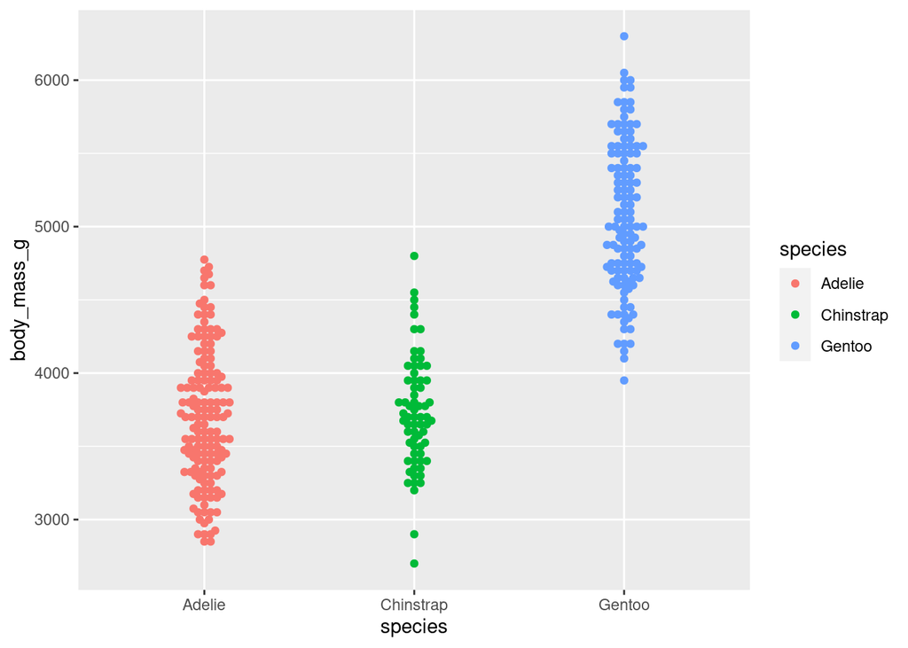

```r
#Using `ggplot2`, make a beeswarm plot of all penguin body masses
#arranged by species. Label the y axis correctly with units and make the points
#partially transparent.
library(ggbeeswarm)
ggplot(data = penguins_df, aes(x = species, y = body_mass_g, color = species)) + geom_beeswarm()
```

```r
#Which species has the most distinctive outlier body masses?
## Chinstrap
```

Let’s assume that we’re curious about the differences between body mass in male and female penguins of a given species. First we’ll try doing this with boxplots and facets.

**Your task:** Using `ggplot2`, make a boxplot of all penguin body masses arranged by sex, with a different facet for each species. Label the y axis correctly with units.

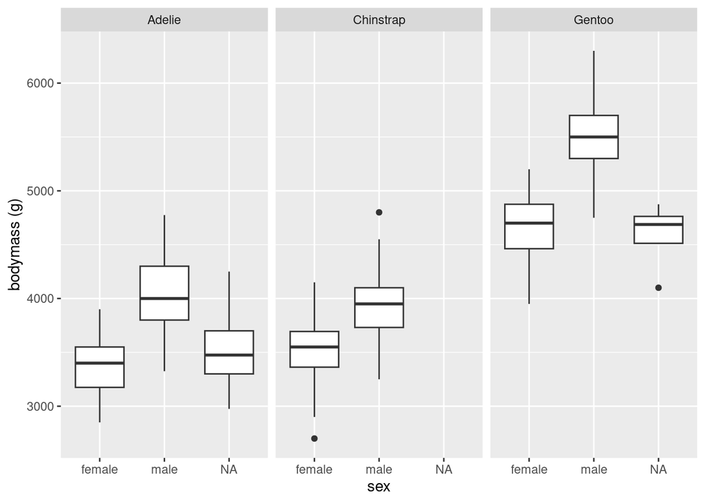

```r
#Using `ggplot2`, make a boxplot of all penguin body masses arranged by species.
#Label the y axis correctly with units.
ggplot(data = penguins_df, aes(x = sex, y = body_mass_g)) + geom_boxplot() + facet_wrap(~species) + labs(y = 'bodymass (g)')
```

Now let’s try the same thing but using a violin plot.

**Your task:** Using `ggplot2`, make a violin plot of all penguin body masses arranged by sex, with a different facet for each species. Label the y axis correctly with units.

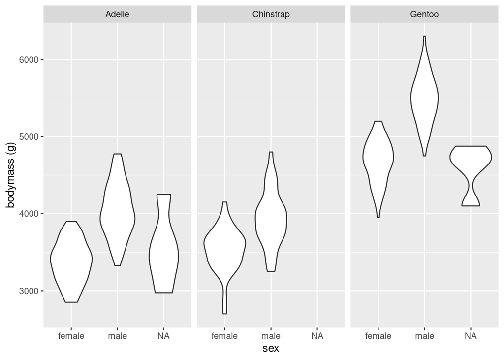

```r
#Using `ggplot2`, make a violin plot of all penguin body masses arranged
#by species. Label the y axis correctly with units.
ggplot(data = penguins_df, aes(x = sex, y = body_mass_g)) + geom_violin() + facet_wrap(~species) + labs(y = 'bodymass (g)')
```

Now let’s try the same thing but using a beeswarm plot. This time you don’t need to use facets, because each individual penguin can be coloured individually.

**Your task:** Using `ggplot2`, make a beeswarm plot of all penguin body masses arranged by species, with a different colour for each species. Label the y axis correctly with units.

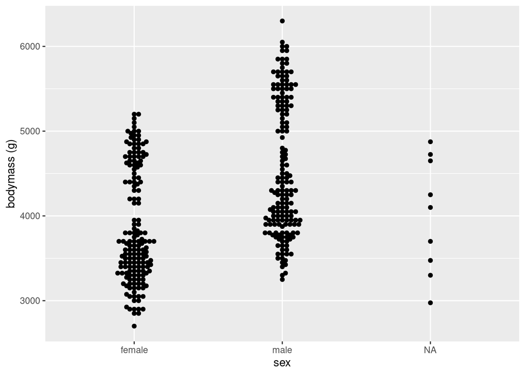

```r
#Using `ggplot2`, make a beeswarm plot of all penguin body masses
#arranged by species, with a different colour for each species. Label the y axis
#correctly with units.
ggplot(data = penguins_df, aes(x = sex, y = body_mass_g)) + geom_beeswarm() + labs(y = 'bodymass (g)')
```

Now think about these three different ways of showing a dataset.

**Your task:** What are the advantages and disadvantages of boxplots, violin plots, and beeswarm plots? What kind of datasets would be best suited for each of these visualisations?

```r
#What are the advantages and disadvantages of boxplots, violin
#plots, and beeswarm plots?
## boxplots shows the median and kvartals, but can hide an underling distribution and size of dataset.
## Violin plots shows the distribution, but hide the number of datapoints.
## beeswarm plot shows both distribution and number of datapoints, but can quickly become crowded.
#What kind of datasets would be best suited for each of these visualisations?
##Boxplots, large and evenly distributet data.
##violin plots, large and unevenly distributed dataset.
## Beesswarm, all datasets that are not too big
```

Finally, we’re going to try and use a graph to critically assess a dataset before working with it. There is an Excel file on Brightspace called `survey_results_practical.xlsx` that you will need.

**Your task:** Upload `survey_results_practical.xlsx` to *posit.cloud* and import it into R. Use it to generate a beeswarm plot showing transport time in minutes for each different transport form. Look carefully at the results - what would make you instantly question the veracity of this dataset, or at least the quality of some of the data points?

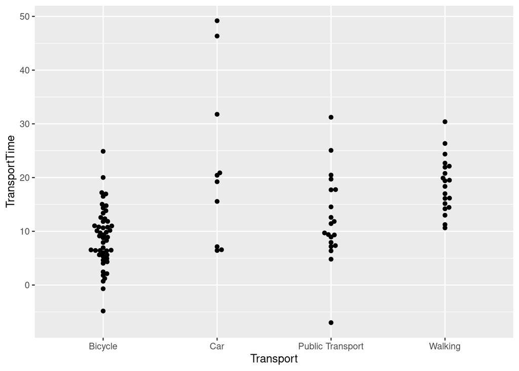

```r
#import the data into R
survey <- read_xlsx('survey_results_practical.xlsx')
#generate a beeswarm plot showing transport time in
#minutes for each different transport form.
ggplot(survey, aes(y = TransportTime, x = Transport)) + geom_beeswarm()
```

```r
#whatwould make you instantly question the veracity of this data set, or at least #some of the data points?
##There are negative transportation time for som datapoints.
```

## Bonus activity: Themes in ggplot2

You can modify almost any aspect of a plot’s appearance by using themes in ggplot2. Built-in themes are listed at https://ggplot2.tidyverse.org/reference/ggtheme.html.

**Your task:** Take one of the plots that you have produced in this practical and apply a theme of your choice.

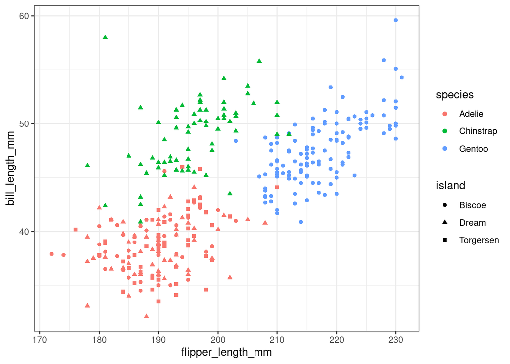

```r
#Apply a theme to a ggplot2 plot
ggplot(penguins_df, aes(flipper_length_mm, bill_length_mm, color = species, shape = island)) + geom_point() + theme_bw()
```

You can also modify any aspect of a theme using the `theme()` function. You can read more about this on https://ggplot2.tidyverse.org/reference/theme.html. Let’s assume that you wanted to change the ggplot2 theme to look more like R base graphics, what would you do? **Hint:** look into the `panel.background` and `panel.border` arguments in `theme()`.

**Your task:** Take one of the plots that you have produced in this practical, remove the grey background and gridlines and add a black border to the plotting area.

```r
#Remove the grey background and add a black border to a ggplot2 plot
```

[output not shown]

## Ugly Plots

Ggplot2 gives you a lot of power over the appearance of your graphics - you can use this power for good, to effectively visualise your data, or for evil, to make your plot as ugly as possible and obfuscating your message. Let’s see what it’s like to be evil - take a plot and make as many modifications as you can to make it ugly - modify fonts, colours, gridlines, borders, backgrounds, whatever you can to make it ugly!

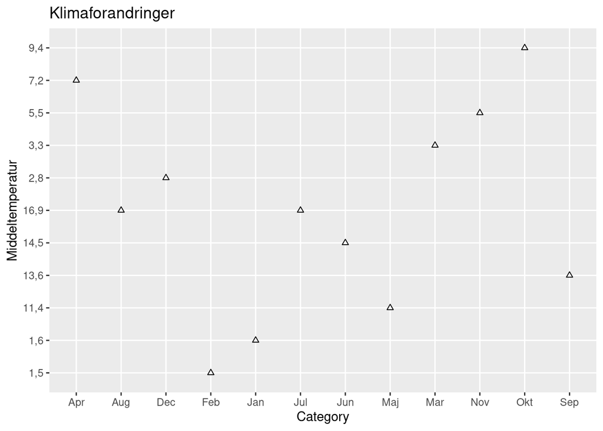

```r
#Make an ugly plot
library(readxl)
vejrdata <- read.csv(file = 'Vejrdata.csv', sep = ';')
library(ggplot2)
p <- ggplot(vejrdata, aes(y = Middeltemperatur, x = Category))
uglyplot <- p + geom_point(shape=24) + ggtitle('Klimaforandringer')
uglyplot
```